# Introdução ao R

# 6 Exportando e importando dados

Os objetos criados dentro do R podem ser exportados em arquivos de diversos formatos. Mas, antes de exportá-los, vamos definir qual é o nosso diretório de trabalho.

## 6.1 Estabelecendo diretório de trabalho

Utilize a aba `Files` para criar uma nova pasta (`New Folder`) chamada `MinicursoR` dentro da pasta `Documents`. Esta será nossa pasta de trabalho, todos os arquivos que exportaremos ou importaremos do R irá automaticamente para esta pasta, mas para isso é necessário informar para o R seu caminho:

```r
setwd("Documents/MinicursoR")
```

Verifique se funcionou:

```r
getwd()
```

## 6.2 Exportação e importação de arquivos

Para exportar o objeto no formato .RData, os quais podem ser lidos pelo R:

```r
save(campo1, file = "campo1.RData")
```

Essa é uma forma de salvar o objeto trabalhado, se removermos ele com:

```r
rm(campo1)  # Certifique-se que salvou o objeto antes de removê-lo
```

Podemos facilmente obtê-lo novamente com:

```r
load("campo1.RData")
```

Para salvar todos os objetos do seu *workspace* use:

```r
save.image()
```

O R irá criar um arquivo `.Rdata` contendo todos os seus objetos.

Podemos exportar nossos objetos em outros formatos, como, por exemplo, `.txt` ou `.csv`. Para isso utilizamos:

```r
write.table(campo1, file = "campo1.txt", sep = ";", dec = ".", row.names = FALSE)
write.csv(campo1, file = "campo1.csv", row.names = TRUE)
```

Ao exportar há diversas opções para a formatação do arquivo, é importante considerá-las se o arquivo for ser trabalhado em outro sofware posteriormente.

Abra os arquivos gerados para visualizar sua formatação.

Esses arquivos podem ser lidos novamente pelo R, utilizando as funções e suas especificações:

```r
campo1_txt <- read.table(file = "campo1.txt", sep=";", dec=".", header = TRUE)
campo1_csv <- read.csv(file = "campo1.csv")
head(campo1_txt)
```

```
##   clone altura diametro idade corte   volume
## 1 GRA02   30.1     0.26     3 FALSE 1.597287
## 2 URO01   30.4     0.30     4 FALSE 2.147760
## 3 URO03   40.0     0.36     5 FALSE 4.069440
## 4 GRA02   30.2     0.24     3 FALSE 1.365523
## 5 GRA01   30.6     0.27     4 FALSE 1.751131
## 6 URO01   40.1     0.35     5  TRUE 3.856116
```

```r
head(campo1_csv)
```

```
##   X clone altura diametro idade corte   volume
## 1 1 GRA02   30.1     0.26     3 FALSE 1.597287
## 2 2 URO01   30.4     0.30     4 FALSE 2.147760
## 3 3 URO03   40.0     0.36     5 FALSE 4.069440
## 4 4 GRA02   30.2     0.24     3 FALSE 1.365523
## 5 5 GRA01   30.6     0.27     4 FALSE 1.751131
## 6 6 URO01   40.1     0.35     5  TRUE 3.856116
```

Agora que aprendemos a importar dados, vamos trabalhar com outro conjunto. Mas antes disso vamos criá-lo.

# 7 Formulário para obtenção de dados

Vamos preencher um formulário do google drive para coletar algumas informações. Caso não queira responder alguma das perguntas, complete com `-` o respectivo campo.

- Acesse [aqui o formulário](https://goo.gl/forms/ZQPBKMjGc08PJ1u72).

A planilha com os dados será disponibilizada em uma pasta específica, adicione-a ao seu diretório de trabalho ou indique o caminho da pasta ao importá-la para dentro do R, como a seguir.

Aqui usaremos o argumento `stringAsFactors` que impede que o R transforme os vetores da tabela em fatores, os quais são mais difíceis de trabalhar. O argumento `na.strings` irá indicar como foram nomeados os dados perdidos.

```r
dados <- read.csv(file = "http://cristianetaniguti.github.io/Workshop_genetica_esalq//praticas_2017/Formulario_resultados.csv", stringsAsFactors = FALSE, na.strings = "-")
head(dados)
```

Vamos explorar a estrutura dos dados coletados:

```r
str(dados)
```

Repare que nos nomes das colunas ainda estão as perguntas completas feitas no formulário, vamos alterar para nomes mais fáceis de trabalhar:

```r
colnames(dados) <- c("Data_pesq", "Idade", "Niver", "Genero", "Cidade",
                     "Altura","Peso", "Area", "Programacao", "Nota")
```

# 8 Paradoxo do aniversário

Nossa primeira análise com esses dados envolverá um problema denominado [“Paradoxo do aniversário”](https://en.wikipedia.org/wiki/Birthday_problem), que afirma que em um grupo de 23 pessoas (ou mais), escolhidas aleatoriamente, há mais de 50% de chance de duas pessoas terem a mesma data de aniversário.

Primeiro, vamos verificar em quantos somos, contando o número de linhas, para isso use a função `nrow`.

```r
nrow(dados)
```

Vamos então verificar se temos no nosso grupo pessoas que compartilham o mesmo dia de aniversário.

Podemos verificar isso facilmente com a função `table`, que indica a frequência de cada observação:

```r
table(dados$Niver)
```

```
##
##      01/03      01/09      05/10 09/08/1996      10/04       10/9
##          1          1          1          1          1          1
##      11/12      13/02      15/02      20/02      20/03      20/07
##          1          1          1          1          1          1
##      20/09 21/02/1995      24/09      24/12      25/07      26/07
##          1          1          1          1          1          1
##      28/04      28/05      29/08      30/12
##          1          1          1          1
```

# 9 Estruturas if, else e for

Para nossa próxima atividade com os dados, vamos primeiro entender como funcionam as estruturas `if`, `else` e `for`.

Nas funções condicionais `if` e `else`, estabelecemos uma condição para if, se ela for verdade a atividade será realizada, caso contrário (else) outra tarefa será. Como no exemplo:

```r
if(2 >3){
  print("dois é maior que três")
} else {
  print("dois não é maior que três")
}
```

- Teste se a 11ª resposta para a penultima pergunta (9ª coluna) foi “não”, se foi, deixe um recado motivacional, caso contrário, parabenize (dica: o sinal `==` se refere a “exatamente igual a”)

```
## [1] "Muito bom!"
```

Mas repare que só é possível utilizar a função para um elemento individual do vetor, se quisermos percorrer o vetor inteiro precisamos recorrer a outro recurso.

Esse recurso pode ser a função `for`, uma função muito utilizada e poderosa. Ela constitui uma estrutura de loop, pois irá aplicar a mesma atividade repetidamente até atingir à uma determinada condição. Veja exemplos:

```r
for(i in 1:10){
  print(i)
}

test <- vector()
for(i in 1:10){
  test[i] <- i+4
}
test
```

Nos casos acima, `i` funciona como um index que irá variar de 1 até 10 a operação determinada entre chaves.

Com essa estrutura, podemos repetir a operação realizada com as estruturas `if` e `else` para todo o vetor:

```r
for(i in 1:nrow(dados))
  if(dados[i,9] == "Sim"){
    print("Muito bom!")
  } else {
    print("Nunca é tarde para começar!")
}
```

# 10 Elaboração de gráficos simples

Para outros dados coletados, vamos gerar alguns gráficos simples utilizando as funções básicas do R. Existem pacotes como o `ggplot2`, `plotly` e `shiny` que possuem ferramentas muito poderosas para construção de gráficos, mas exigem um pouco mais de tempo para aprendizagem de sua sintaxe.

Vamos iniciar com um simples gráfico de frequências (ou histograma) para os dados de `idade`.

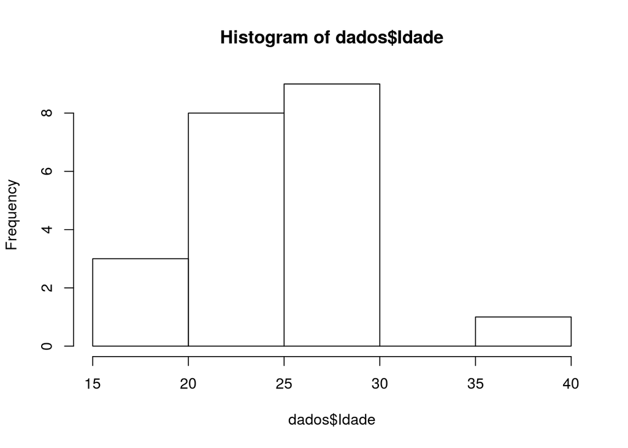

```r
hist(dados$Idade)
```

Vamos adicionar alguns argumentos para dar uma personalizada:

- `breaks` para definir os intervalos para cada barra;
- `col` para adicionar cor;
- `xlab` alterar título do eixo x;
- `ylab` alterar título do eixo y;
- `main` alterar título geral;

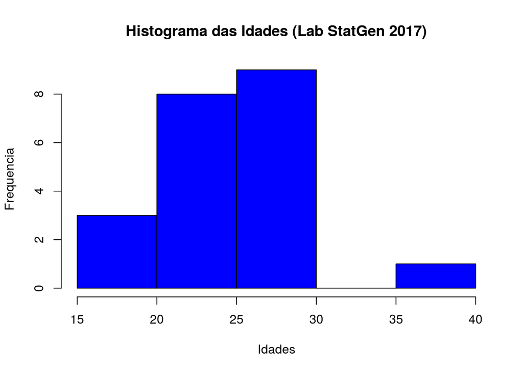

```r
hist(dados$Idade, breaks=6, col="blue", xlab="Idades",
     ylab="Frequencia", main="Histograma das Idades (Lab StatGen 2017)")
```

Se preferir, podemos usar um gráfico de densidades de Kernel como:

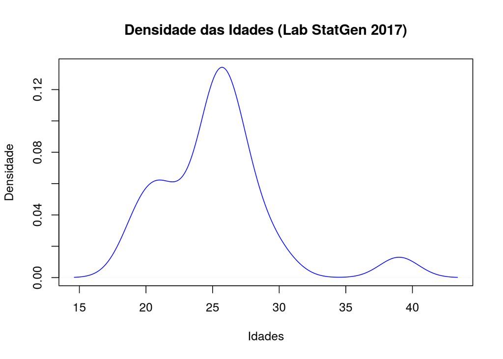

```r
d <- density(dados$Idade, na.rm = TRUE)

plot(d, col="blue", xlab="Idades",
     ylab="Densidade", main="Densidade das Idades (Lab StatGen 2017)")
```

Alguns argumentos são específicos para cada função, busque mais informações sobre cada uma delas para entender sobre seus argumentos.

Podemos também fazer um gráfico de barras para a resposta `Area` usando:

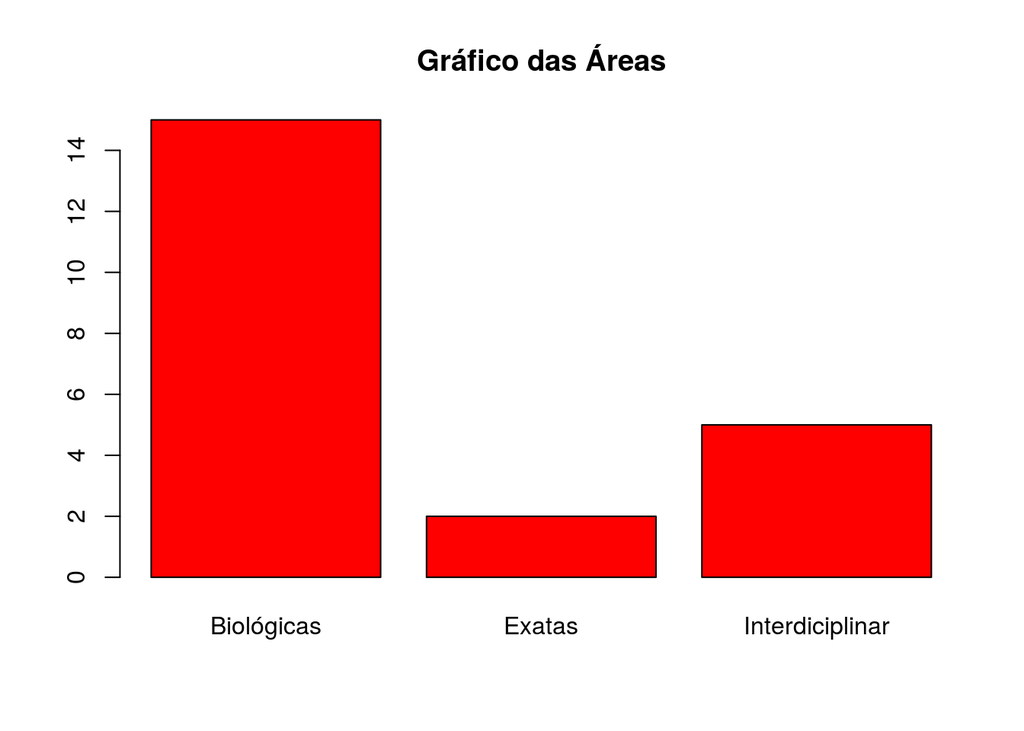

```r
contagens <- table(dados$Area)
barplot(contagens, col= "red", main="Gráfico das Áreas")
```

Com esse tipo de gráfico é possível diferenciar colorações para diferentes categorias, como:

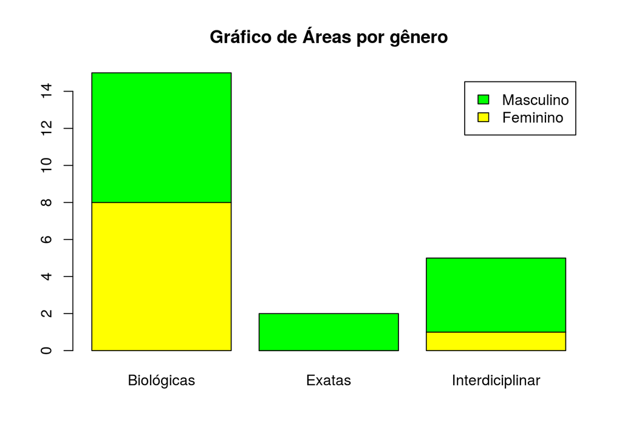

```r
contagens <- table(dados$Genero, dados$Area)
barplot(contagens, col= c("yellow", "green", "red"), main="Gráfico de Áreas por gênero",
        legend = rownames(contagens))
```

Ou podem ser gerados lado a lado:

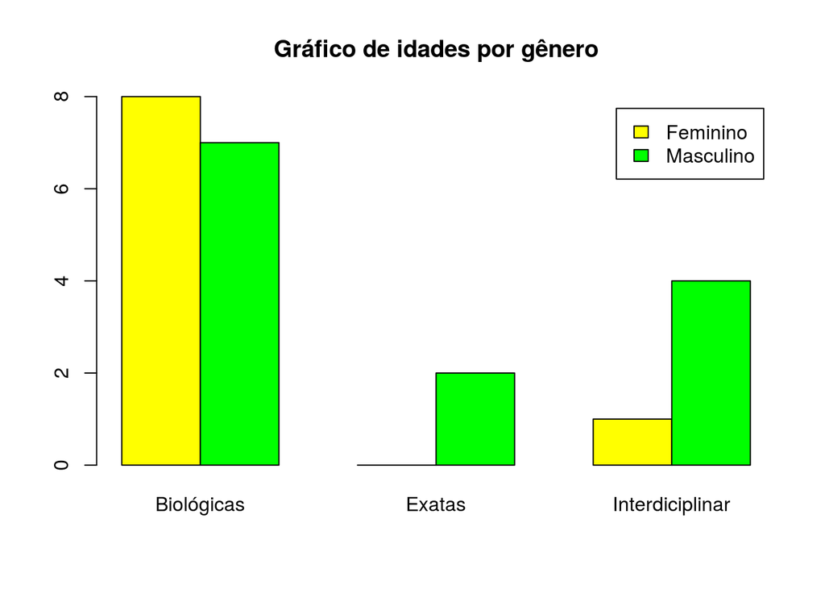

```r
contagens <- table(dados$Genero, dados$Area)
barplot(contagens, col= c("yellow", "green"), main="Gráfico de idades por gênero",
        legend = rownames(contagens), beside = TRUE)
```

Na horizontal:

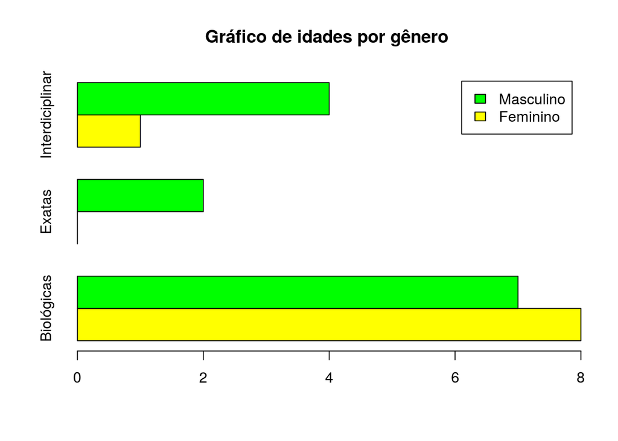

```r
contagens <- table(dados$Genero, dados$Area)
barplot(contagens, col= c("yellow", "green"), main="Gráfico de idades por gênero",
        legend = rownames(contagens), beside = TRUE, horiz = TRUE)
```

Vamos utilizar um boxplot para avaliar as `Nota`:

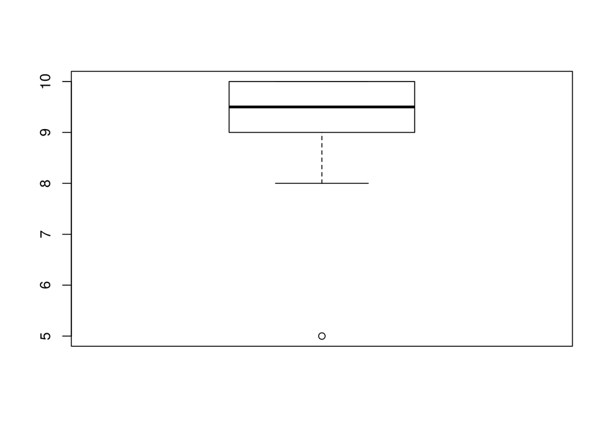

```r
boxplot(dados$Nota)
```

Sabe- se que existe uma correlação entre o peso e a altura das pessoas, e que, a distribuição dessas características configura uma bimodal se não considerarmos os gênero dos indivíduos avaliados. Vamos avaliar a correção entre essas caraterísticas com:

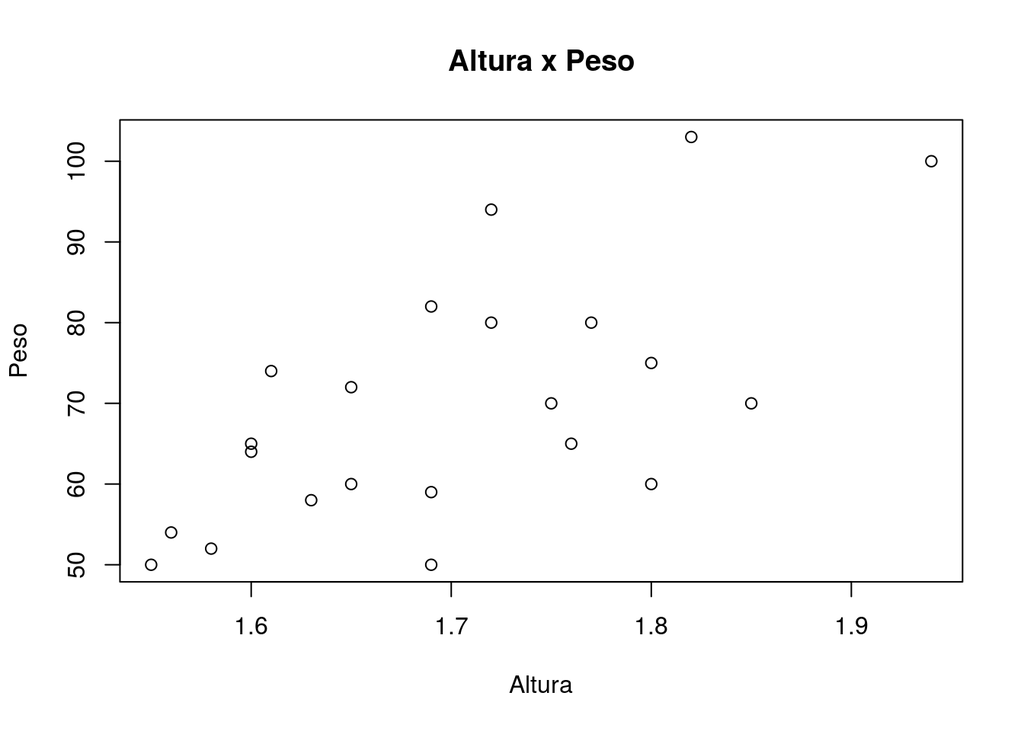

```r
plot(dados$Altura, dados$Peso, main = "Altura x Peso", xlab = "Altura", ylab = "Peso")
```

Verificando o valor da correlação:

```r
cor(dados$Altura, dados$Peso)
```

```
## [1] 0.6486322
```

Agora vamos verificar a distribuição delas, primeiro com todos os gêneros e posteriormente separando masculino e feminino.

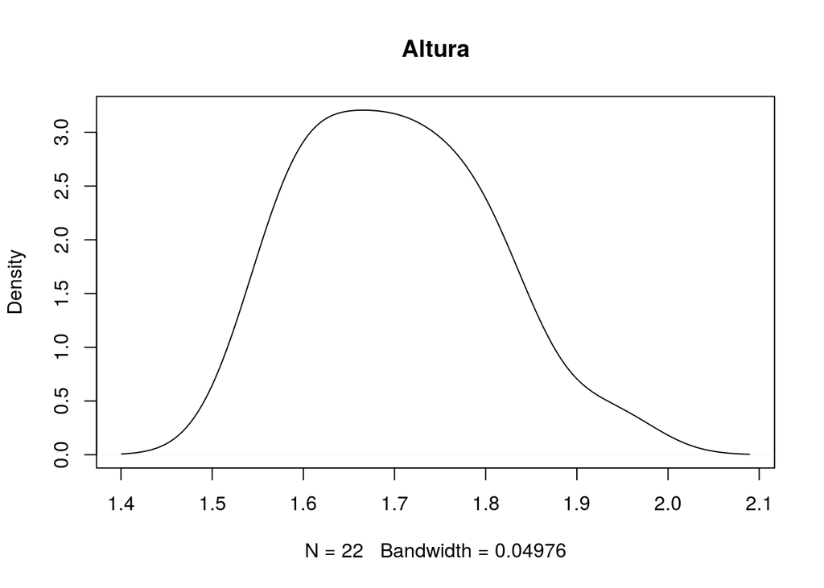

```r
Alt_total <- density(dados$Altura, na.rm = TRUE)  # Todos os dados de altura
plot(Alt_total, main="Altura")
```

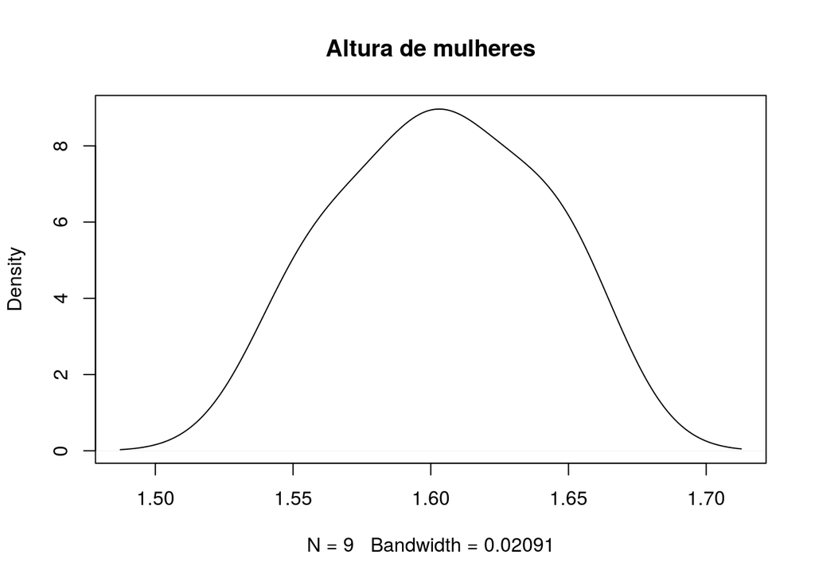

```r
pos_fem <- which(dados$Genero=="Feminino")   # Linhas referentes ao genero feminino
pos_masc <- which(dados$Genero=="Masculino") # Linhas referentes ao genero masculino


Alt_fem <- density(dados$Altura[pos_fem], na.rm = TRUE)   # Somente dados de altura de mulheres
plot(Alt_fem, main="Altura de mulheres")
```

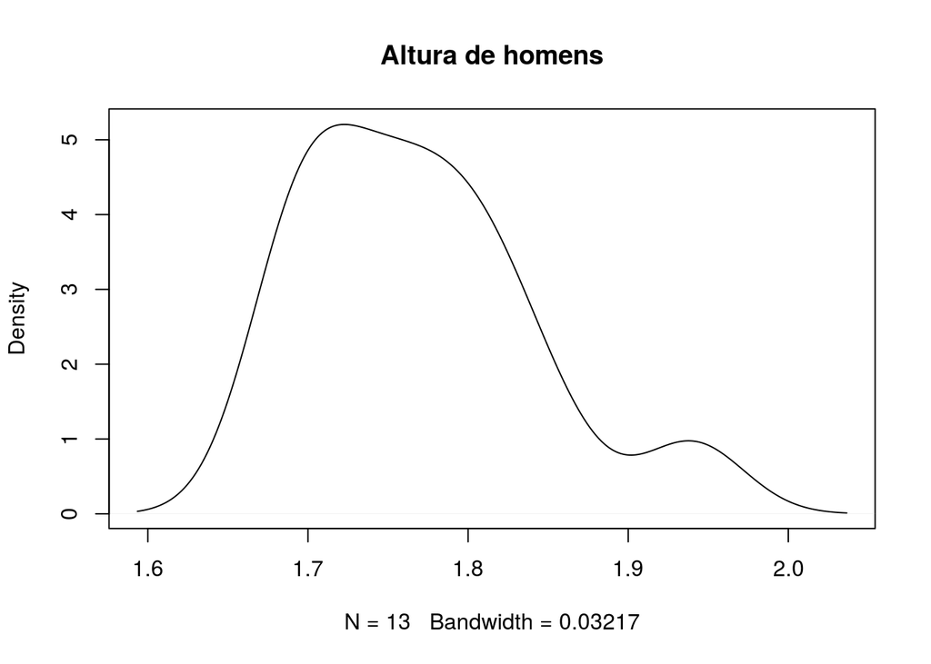

```r
Alt_masc <- density(dados$Altura[pos_masc], na.rm = TRUE) # Somente dados de altura de homens
plot(Alt_masc, main="Altura de homens")
```

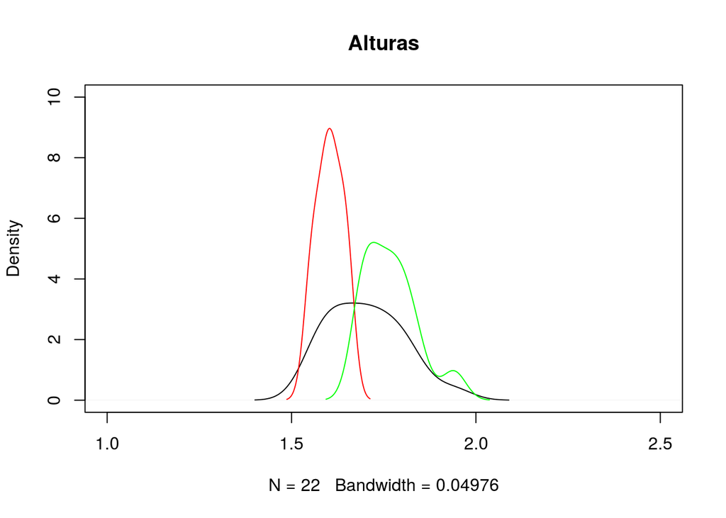

```r
plot(Alt_total, col="black",ylim=c(0,10),xlim=c(1,2.5), main="Alturas")
lines(Alt_fem, col="red")
lines(Alt_masc, col="green")
```

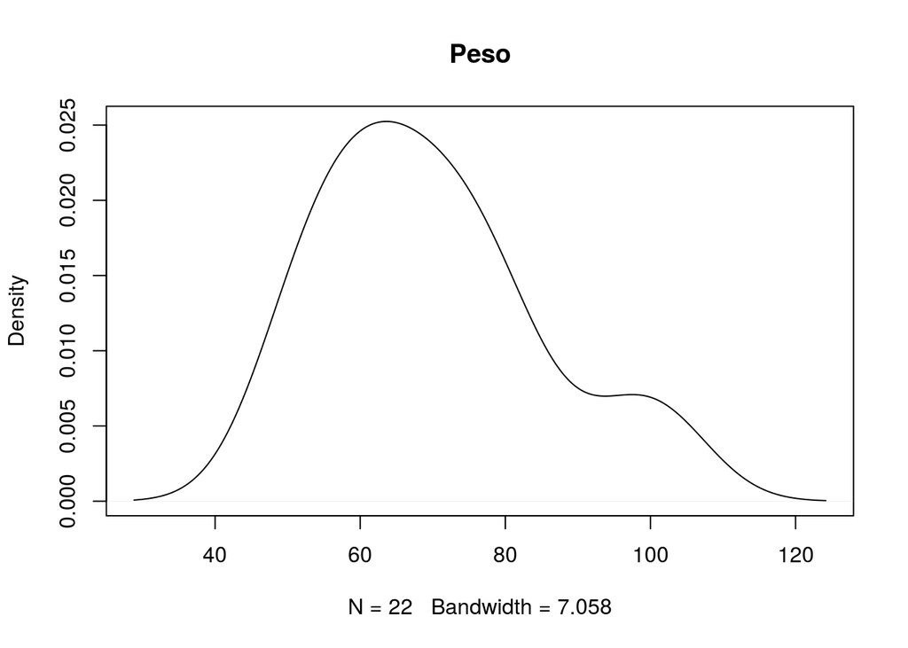

```r
### Fazendo o mesmo gráfico para peso

Peso_total <- density(dados$Peso, na.rm = TRUE)   # Todos os dados de peso
plot(Peso_total, main="Peso")
```

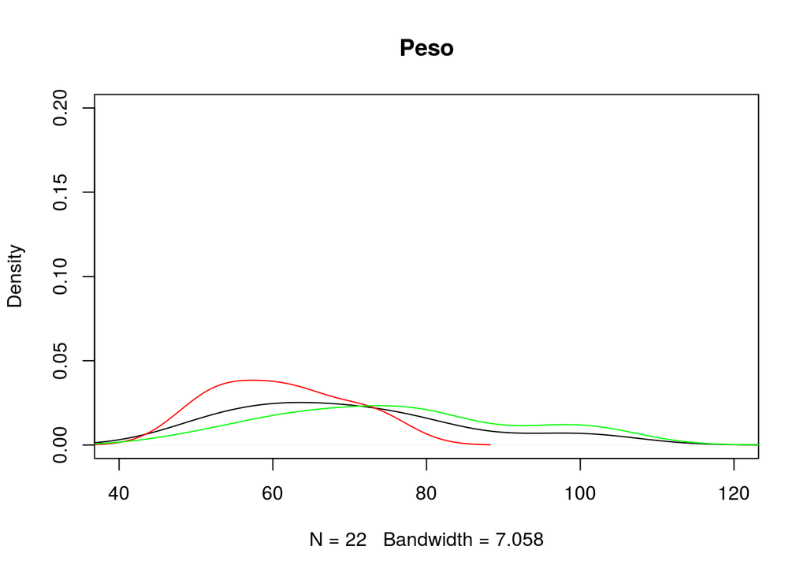

```r
Peso_fem <- density(dados$Peso[pos_fem], na.rm = TRUE)   # Peso das mulheres
Peso_masc <- density(dados$Peso[pos_masc], na.rm = TRUE) # Peso dos homens

plot(Peso_total, col="black",ylim=c(0,0.2),xlim=c(40,120), main="Peso")
lines(Peso_fem, col="red")
lines(Peso_masc, col="green")
```

Ajuste os eixos `xlim` e `ylim` da forma que achar conveniente. Obtidos todos esses gráficos, pode ser bom para visualização tê-los lado a lado.

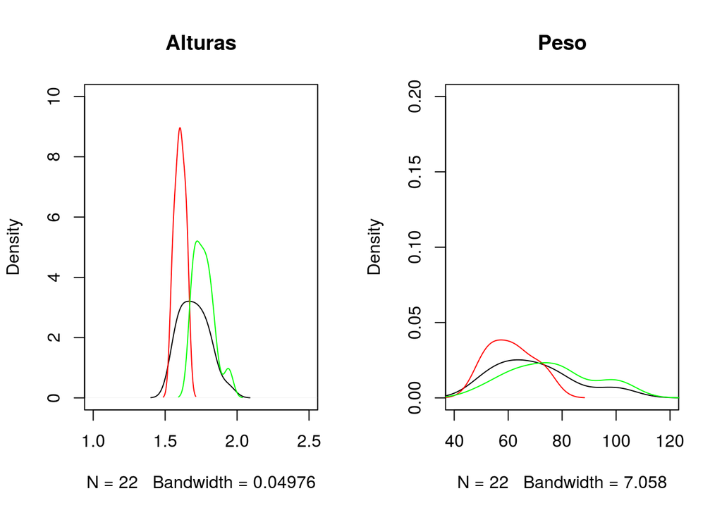

```r
par(mfrow=c(1,2))

plot(Alt_total, col="black",ylim=c(0,10),xlim=c(1,2.5), main="Alturas")
lines(Alt_fem, col="red")
lines(Alt_masc, col="green")

plot(Peso_total, col="black",ylim=c(0,0.2),xlim=c(40,120), main="Peso")
lines(Peso_fem, col="red")
lines(Peso_masc, col="green")
```

# 11 Instalação e aplicações de pacotes

Existem diversos pacotes disponíveis para variadas aplicações. Aqui usaremos o pacote `ggmap`.

Ele esta disponível no repositório oficial do R, o CRAN, portanto para instalá-lo basta:

```r
install.packages("ggmap")
```

Depois disso é necessário recrutá-lo com:

```r
library(ggmap) # Este comando será necessário toda vez que for utilizar o pacote
```

É um pacote que utiliza recursos online para gerar mapas conforme um conjunto de dados. Você pode obter mais informações sobre ele no [manual disponível no CRAN](https://cran.r-project.org/web/packages/ggmap/ggmap.pdf).

Vamos utilizar a função `geocode` para obter dados de longitude e latitude das cidades dos participantes do curso:

```r
part1 <- geocode(dados$Cidade[1])
```

Podemos aplicar a mesma função para todos os participantes utilizando o `for`.

```r
coord <- data.frame()
for(i in 1:nrow(dados)){
  coord <- rbind(coord,geocode(dados$Cidade[i]))
}
```

```
## .
```

```
## .
```

Agora estabelecemos um mapa de fundo com a média das longitudes e latitudes:

```r
mapcurso <- get_map(location =
                    c(lon = mean(coord$lon),
                    lat = mean(coord$lat)),
                    zoom = 4,
                    maptype = "roadmap", scale = 2)
```

Para mais informações sobre as funções do pacote utilize `?get_map`.

Agora vamos adicionar as localizações no mapa:

[figure not shown]

```r
ggmap(mapcurso) +
  geom_point(data = coord,
             aes(x = lon, y = lat, fill = "red"),
             size = 2, shape = 21)
```

Aqui os argumentos de `aes` definem características dos pontos no mapa, `fill` indica a coloração, `size` o tamanho e `shape` o formato. Acesse outras codificações de formato [aqui](http://www.cookbook-r.com/Graphs/Shapes_and_line_types/).

# 12 Pratique gerando relatórios no RStudio

Utilize o R no seu dia-a-dia para ir praticando a linguagem. Além das recomendações contidas na [primeira apresentação](http://cristianetaniguti.github.io/Workshop_genetica_esalq//teoricas_2017/Why_R.html), recomendamos também dar uma olhada em como gerar documentos em pdf e html usando a Markdown. Utilizamos essa metodologia para gerar este tutorial e outras apresentações do minicurso. Pode ser muito prático no dia-a-dia!

Recentemente foi publicado um tutorial sobre isso no R-bloggers, que acreditamos ser um bom começo! Acesse [aqui](https://www.r-bloggers.com/how-to-create-reports-with-r-markdown-in-rstudio/).